# Toddler Uncertainty Monitoring

Emily

2016-11-23

Data analysis of toddler uncertainty monitoring study.

# 1 Data preprocessing

Preliminaries.

Read in trial info, demographics, and word familiarity.

```r
demo <- read.csv("demographics.csv")
trial_info <- read.csv("conditions.csv", header = TRUE)
trial_info$trial <- as.character(trial_info$trial)

word_fam_key <- read.csv("word_fam_key.csv")
word_fam_key$trial <- as.character(word_fam_key$trial)

word_fam <- read.csv("word_familiarity.csv") %>%
  gather("target", "familiarity", 2:41 )

response_key <- read.csv("response_key.csv")
response_key$trial <- as.character(response_key$trial)
```

Read in TS data file.

```r
d.raw_ts <- read.table("AllSubs_TS.txt", header = TRUE)
```

Make TS data tidy.

```r
d_acc_ts<- d.raw_ts %>%
  select(Subject_ID, acc1, acc2, acc3, acc4, acc5, acc6, acc7, acc8, acc9, acc10, acc11, acc12, acc13, acc14, acc15, acc16, acc17, acc18, acc19, acc20)%>%
  gather(trial, acc, acc1:acc20)

d_rt <- d.raw_ts %>%
  select(Subject_ID, RT1, RT2, RT3, RT4, RT5, RT6, RT7, RT8, RT9, RT10, RT11, RT12, RT13, RT14, RT15, RT16, RT17, RT18, RT19, RT20) %>%
  gather(trial, RT, RT1:RT20)

d_acc_ts$trial <-str_replace(d_acc_ts$trial, "acc","")
d_rt$trial <- str_replace(d_rt$trial, "RT","")

d_ts <- d_acc_ts %>%
  left_join(d_rt) %>%
  mutate(ID = Subject_ID) %>%
  select(ID, RT, acc, trial)

d_ts$acc[d_ts$acc==999] <- NA
```

Join trial info and demographics with raw TS data.

```r
d_ts <- left_join(d_ts, trial_info) %>%
  left_join(demo) %>%
  select(-participation_date, -birthdate) %>%
  left_join(word_fam_key) %>%
  left_join(word_fam) %>%
  left_join(response_key) %>%
  filter(drop != 1)

d_ts <- d_ts %>%
  mutate(similar = ifelse(similarity == 1, "similar",
                                       "dissimilar")) %>%
  select(-similarity)
```

```r
d_ts$ID <- as.factor(as.character(d_ts$ID))
length(levels(d_ts$ID))
```

```
## [1] 73
```

There are 73 touchscreen participants.

Read in ET data.

```r
d.raw_et <- read.csv("AllSubs_ET.csv", header = TRUE)
d.raw_sw <- read.csv("perceptual_transitions.csv", header = TRUE)
d.raw_sw$ID <- d.raw_sw$Subject
```

Make data ET tidy and join trial info and demographics with raw data.

```r
d.raw_sw <- d.raw_sw %>%
  gather(trial, trans, Trial1:Trial20) %>%
  select(-Subject)
```

```r
d.raw_sw$ID <- as.factor(as.character(d.raw_sw$ID))
length(levels(d.raw_sw$ID))
```

```
## [1] 95
```

There are 95 eyetracker participants with transitions data including pilots and others to-be-excluded.

```r
d.raw_et$ID <- as.factor(as.character(d.raw_et$ID))
length(levels(d.raw_et$ID))
```

```
## [1] 88
```

There are 88 eyetracker participants with accuracy data including pilots and others to-be-excluded.

Join ET transitions and accuracy data and drop excluded participants (including pilots).

```r
d.raw_sw$trial <- str_replace(d.raw_sw$trial, "Trial","")
d.raw_et$trial <- as.character(d.raw_et$trial)

d.raw_et <- d.raw_et %>%
  select(ID, trial, acc)

d.raw_sw$ID <- as.character(d.raw_sw$ID)
d.raw_et$ID <- as.character(d.raw_et$ID)
demo$ID <- as.character(demo$ID)
word_fam$ID <- as.character(word_fam$ID)

d_et <- d.raw_et %>%
  inner_join(d.raw_sw) %>%
  mutate(acc_et = acc) %>%
  left_join(demo) %>%
  left_join(trial_info)%>%
  select(-participation_date, -birthdate) %>%
  left_join(word_fam_key) %>%
  left_join(word_fam) %>%
  left_join(response_key) %>%
  filter(drop != 1) %>%
  select(-acc)

d_et <- d_et %>%
  mutate(similar = ifelse(similarity == 1, "similar",
                                       "dissimilar")) %>%
  select(-similarity)
```

```r
d_et$ID <- as.factor(as.character(d_et$ID))
length(levels(d_et$ID))
```

```
## [1] 71
```

There are 71 eyetracker participants with both transitions and accuracy data.

Merge TS and ET data and drop excluded participants (including pilots).

```r
d <- d_ts %>%
  full_join(d_et) %>%
  filter(drop != 1)
```

```r
d$ID <- as.factor(as.character(d$ID))
length(levels(d$ID))
```

```
## [1] 80
```

There are 80 participants with *either* eyetracker or touchscreen data.

# 2 Demographics

```r
summary(demo_drop$income)
```

```
##                     <15,000 15,000-25,000 25,000-40,000 40,000-60,000
##             3             1             4             7            16
## 60,000-90,000       >90,000
##            16            33
```

```r
summary(demo_drop$race)
```

```
##
##                                     12
##                       African American
##                                      1
##             African American/Caucasian
##                                      3
## American Indian or Alaskan / Caucasian
##                                      1
##                                  Asian
##                                      1
##                      Asian & Caucasian
##                                      2
##                    Asian and Caucasian
##                                      1
##                       Asian, Caucasian
##                                      1
##                        Asian/Caucasian
##                                      1
##                              Caucasian
##                                     46
##                             Caucasian
##                                      3
##            Native Hawaiian & Caucasian
##                                      3
##                       Pacific Islander
##                                      0
##                                SKIPPED
##                                      0
##                                   NA's
##                                      5
```

```r
summary(demo_drop$gender)
```

```
##          Female  Female    Male   Male
##       1       1      37      36       5
```

```r
psych::describe(demo_drop$age_months)
```

```
##   vars  n  mean   sd median trimmed  mad   min   max range skew kurtosis
## 1    1 80 28.84 1.79  28.62   28.73 1.96 25.68 34.16  8.48 0.48    -0.34
##    se
## 1 0.2
```

# 3 Accuracy

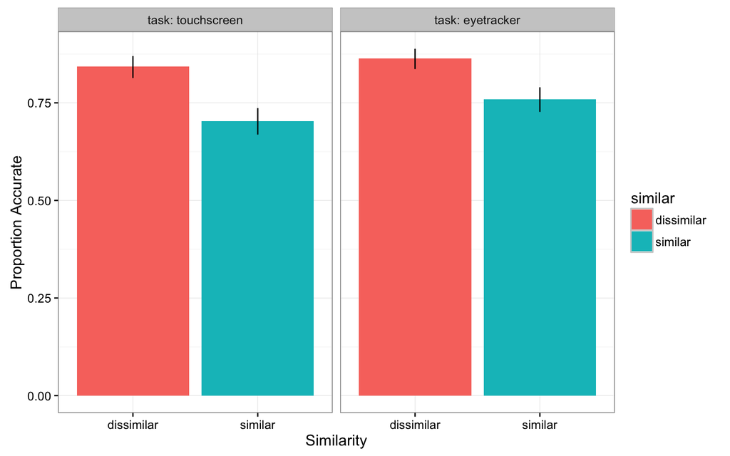

Get mean accuracy by task and similarity.

```r
d_acc_et <- d_compare %>%
  filter(task == "eyetracker")
d_acc_ts <- d_compare %>%
  filter(task == "touchscreen")
```

Accuracy for eyetracker

```r
psych::describeBy(d_acc_et$acc, d_acc_et$similar)
```

```
## group: dissimilar
##   vars   n mean   sd median trimmed mad min max range  skew kurtosis   se
## 1    1 669 0.86 0.34      1    0.95   0   0   1     1 -2.12     2.49 0.01
## --------------------------------------------------------
## group: similar
##   vars   n mean   sd median trimmed mad min max range  skew kurtosis   se
## 1    1 671 0.76 0.43      1    0.82   0   0   1     1 -1.21    -0.55 0.02
```

Accuracy for touchscreen

```r
psych::describeBy(d_acc_ts$acc, d_acc_ts$similar)
```

```
## group: dissimilar
##   vars   n mean   sd median trimmed mad min max range  skew kurtosis   se
## 1    1 694 0.84 0.36      1    0.93   0   0   1     1 -1.88     1.54 0.01
## --------------------------------------------------------
## group: similar
##   vars   n mean   sd median trimmed mad min max range  skew kurtosis   se
## 1    1 701  0.7 0.46      1    0.75   0   0   1     1 -0.89    -1.21 0.02
```

# 4 Eyetracker data

Filter missing data and unfamiliar trials.

```r
d_et_filt <- d_et %>%
  mutate(acc = acc_et)%>%
  select(-acc_et)%>%
  filter(!is.na(trans),
         !is.na(acc),
         familiarity != 0)
```

Plot distribution (density) of transitions (switches) by accuracy and similarity.

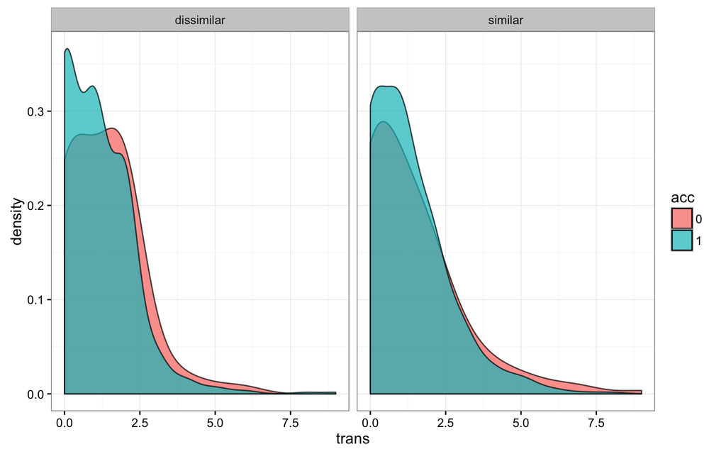

Plot proportion accurate by similarity.

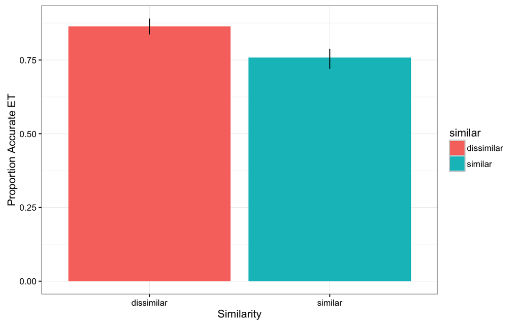

Plot the mean number of transitions (switches) by accuracy and similarity.

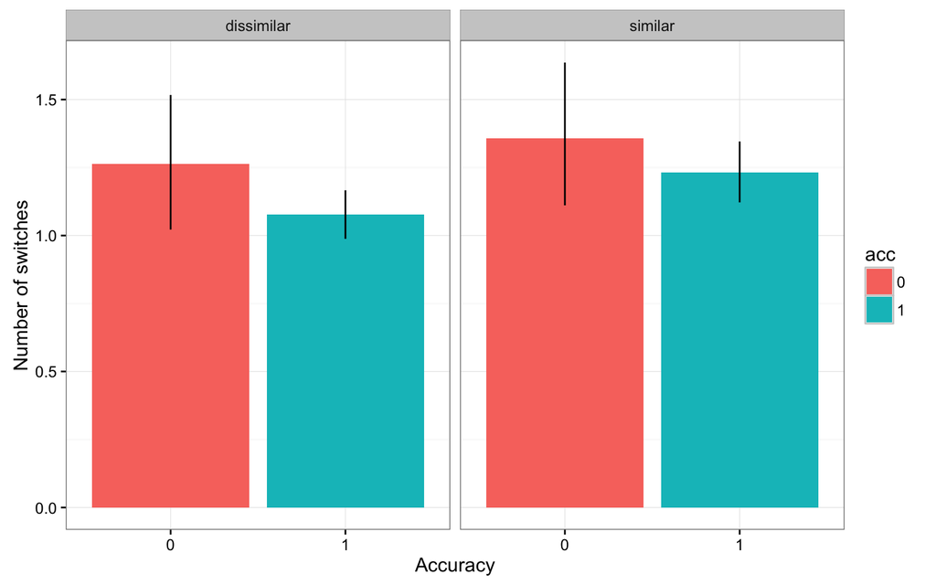

## 4.1 Analyses

Linear mixed-effects models predicting switch count based on similarity and accuracy.

```r
#more complex random effects structures fail to converge.
#expect random effects slopes to vary more for ID than target- effects of similarity and accuracy should vary more by participant than target.

d_et_filt$acc <- as.numeric(d_et_filt$acc)

glm_trans_full <- lmer(trans ~ similar + acc +
                          (similar + acc | ID),
                         data = d_et_filt, REML = FALSE)

glm_trans_interaction <- lmer(trans ~ similar * acc +
                          (similar + acc | ID),
                         data = d_et_filt, REML = FALSE)

glm_trans_sim <- lmer(trans ~ similar +
                          (similar + acc | ID),
                         data = d_et_filt, REML = FALSE)

glm_trans_acc <- lmer(trans ~ acc +
                          (similar + acc | ID),
                         data = d_et_filt, REML = FALSE)

glm_trans_age <- lmer(trans ~ similar + acc + age_months +
                          (similar + acc | ID),
                         data = d_et_filt, REML = FALSE)

glm_trans_age_sim <- lmer(trans ~  acc + similar * age_months +
                          (similar + acc | ID),
                         data = d_et_filt, REML = FALSE)

glm_trans_age_acc <- lmer(trans ~ similar + acc * age_months +
                          (similar + acc | ID),
                         data = d_et_filt, REML = FALSE)
```

Summary of maximal model (withinteraction term).

```r
summary(glm_trans_interaction)
```

```
## Linear mixed model fit by maximum likelihood  ['lmerMod']
## Formula: trans ~ similar * acc + (similar + acc | ID)
##    Data: d_et_filt
##
##      AIC      BIC   logLik deviance df.resid
##   4338.0   4395.1  -2158.0   4316.0     1328
##
## Scaled residuals:
##     Min      1Q  Median      3Q     Max
## -2.0824 -0.6736 -0.2154  0.5159  6.4350
##
## Random effects:
##  Groups   Name           Variance Std.Dev. Corr
##  ID       (Intercept)    2.13691  1.4618
##           similarsimilar 0.02172  0.1474    0.70
##           acc            0.50513  0.7107   -0.96 -0.49
##  Residual                1.31608  1.1472
## Number of obs: 1339, groups:  ID, 71
##
## Fixed effects:
##                    Estimate Std. Error t value
## (Intercept)         1.50743    0.32137   4.691
## similarsimilar      0.08951    0.33142   0.270
## acc                -0.21744    0.16487  -1.319
## similarsimilar:acc  0.03553    0.17655   0.201
##
## Correlation of Fixed Effects:
##             (Intr) smlrsm acc
## similarsmlr -0.629
## acc         -0.979  0.639
## smlrsmlr:cc  0.628 -0.980 -0.651
```

Fixed effects coeffiencients for full model.

|  | Estimate | Std. Error | t value |
| --- | --- | --- | --- |
| (Intercept) | 1.51 | 0.32 | 4.69 |
| similarsimilar | 0.09 | 0.33 | 0.27 |
| acc | -0.22 | 0.16 | -1.32 |
| similarsimilar:acc | 0.04 | 0.18 | 0.20 |

Compare model fits as significance test.

Test for effect of accuracy.

|  | Df | AIC | BIC | logLik | deviance | Chisq | Chi Df | Pr(>Chisq) |
| --- | --- | --- | --- | --- | --- | --- | --- | --- |
| glm_trans_sim | 9 | 4336.387 | 4383.184 | -2159.193 | 4318.387 | NA | NA | NA |
| glm_trans_full | 10 | 4335.994 | 4387.990 | -2157.997 | 4315.994 | 2.393194 | 1 | 0.1218644 |

Test for effect of similarity.

|  | Df | AIC | BIC | logLik | deviance | Chisq | Chi Df | Pr(>Chisq) |
| --- | --- | --- | --- | --- | --- | --- | --- | --- |
| glm_trans_acc | 9 | 4339.348 | 4386.145 | -2160.674 | 4321.348 | NA | NA | NA |
| glm_trans_full | 10 | 4335.994 | 4387.990 | -2157.997 | 4315.994 | 5.354766 | 1 | 0.0206657 |

Test for effect of interaction between accuracy and similarity.

|  | Df | AIC | BIC | logLik | deviance | Chisq | Chi Df | Pr(>Chisq) |
| --- | --- | --- | --- | --- | --- | --- | --- | --- |
| glm_trans_full | 10 | 4335.994 | 4387.99 | -2157.997 | 4315.994 | NA | NA | NA |
| glm_trans_interaction | 11 | 4337.953 | 4395.15 | -2157.977 | 4315.953 | 0.0403625 | 1 | 0.8407734 |

Test for effect of age

|  | Df | AIC | BIC | logLik | deviance | Chisq | Chi Df | Pr(>Chisq) |
| --- | --- | --- | --- | --- | --- | --- | --- | --- |
| glm_trans_full | 10 | 4335.994 | 4387.990 | -2157.997 | 4315.994 | NA | NA | NA |
| glm_trans_age | 11 | 4337.290 | 4394.487 | -2157.645 | 4315.290 | 0.7033184 | 1 | 0.4016709 |

Test for effect interaction of age and sim

|  | Df | AIC | BIC | logLik | deviance | Chisq | Chi Df | Pr(>Chisq) |
| --- | --- | --- | --- | --- | --- | --- | --- | --- |
| glm_trans_age | 11 | 4337.290 | 4394.487 | -2157.645 | 4315.290 | NA | NA | NA |
| glm_trans_age_sim | 12 | 4339.102 | 4401.498 | -2157.551 | 4315.102 | 0.188396 | 1 | 0.664255 |

Test for effect interaction of age and acc

|  | Df | AIC | BIC | logLik | deviance | Chisq | Chi Df | Pr(>Chisq) |
| --- | --- | --- | --- | --- | --- | --- | --- | --- |
| glm_trans_age | 11 | 4337.290 | 4394.487 | -2157.645 | 4315.290 | NA | NA | NA |
| glm_trans_age_acc | 12 | 4339.198 | 4401.594 | -2157.599 | 4315.198 | 0.092155 | 1 | 0.7614552 |

Similarity affected switch count (*χ2(1)*=5.35, *p*=0.02) , such that similarity (compared to dissimilarity) added 0.15 (SE = 0.07) switches. Accuracy was not a significant predictor, and accuracy and similarity did not interact.

Get mean transitions by similarity and accuracy.

```r
describeBy(d_et_filt$trans, d_et_filt$similar)
```

```
## group: dissimilar
##   vars   n mean   sd median trimmed  mad min max range skew kurtosis   se
## 1    1 668  1.1 1.16      1    0.96 1.48   0   9     9 1.67      5.9 0.04
## --------------------------------------------------------
## group: similar
##   vars   n mean   sd median trimmed  mad min max range skew kurtosis   se
## 1    1 671 1.26 1.39      1    1.04 1.48   0   9     9 1.61     3.61 0.05
```

```r
describeBy(d_et_filt$trans, d_et_filt$acc)
```

```
## group: 1
##   vars   n mean   sd median trimmed  mad min max range skew kurtosis   se
## 1    1 253 1.32 1.48      1    1.08 1.48   0   9     9  1.7      4.1 0.09
## --------------------------------------------------------
## group: 2
##   vars    n mean   sd median trimmed  mad min max range skew kurtosis   se
## 1    1 1086 1.15 1.23      1    0.96 1.48   0   9     9 1.61      4.5 0.04
```

Accuracy and similarity are correlated. Let’s look at the similarity effect separately for accurate and inaccurate trials. To do this we will conduct a paired-samples t-test on the average number of transitions for similar vs. dissimilar trials, first for the accurate trials, and then for the inaccurate trials.

```r
d_et_filt$acc <- as.character(d_et_filt$acc)

#accurate trials
d_et_filt_t <- filter(d_et_filt, acc == "2") %>%
  select(ID, trial, trans, similar) %>%
  group_by(ID, similar) %>%
  summarise(trans = mean(trans)) %>%
  spread(similar, trans)

# paired t-test
test_acc <- t.test(d_et_filt_t$similar, d_et_filt_t$dissimilar,paired=TRUE)
test_acc
```

```
##
##  Paired t-test
##
## data:  d_et_filt_t$similar and d_et_filt_t$dissimilar
## t = 2.8623, df = 69, p-value = 0.005564
## alternative hypothesis: true difference in means is not equal to 0
## 95 percent confidence interval:
##  0.07599024 0.42556305
## sample estimates:
## mean of the differences
##               0.2507766
```

```r
#inaccurate trials
d_et_filt_t <- filter(d_et_filt, acc == "1") %>%
  select(ID, trial, trans, similar) %>%
  group_by(ID, similar) %>%
  summarise(trans = mean(trans)) %>%
  spread(similar, trans)%>%
  filter(!is.na(similar))%>%
  filter(!is.na(dissimilar))

# paired t-test
test_inacc <- t.test(d_et_filt_t$similar, d_et_filt_t$dissimilar,paired=TRUE)
test_inacc
```

```
##
##  Paired t-test
##
## data:  d_et_filt_t$similar and d_et_filt_t$dissimilar
## t = 1.5155, df = 43, p-value = 0.137
## alternative hypothesis: true difference in means is not equal to 0
## 95 percent confidence interval:
##  -0.1117390  0.7874966
## sample estimates:
## mean of the differences
##               0.3378788
```

The effect of similarity was significant among accurate trials, *t* = 2.86, *p* = 0.01, but not inaccurate trials, *t* = 1.52, *p* = 0.14.

```r
d_et_filt$acc <- as.numeric(as.character(d_et_filt$acc))

d_et_filt_id <- d_et_filt %>%
  group_by(ID) %>%
  mutate(trans_acc = mean(trans[acc == 1])) %>%
  mutate(trans_inacc = mean(trans[acc == 0])) %>%
  mutate(trans_sim = mean(trans[similar == "similar"])) %>%
  mutate(trans_dissim = mean(trans[similar == "dissimilar"])) %>%
  mutate(trans_acc_diff = trans_inacc - trans_acc) %>%
  mutate(trans_sim_diff = trans_sim - trans_dissim) %>%
  mutate(avg_acc = mean(acc))
```

[figure not shown]

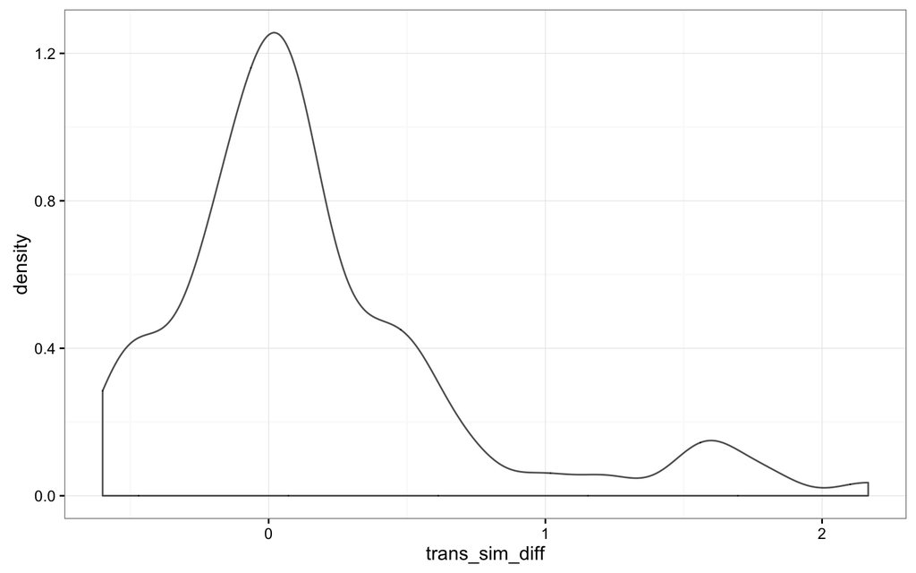

Correlate differentials with accuracy.

```r
d_et_filt_id <- d_et_filt_id %>%
  select(ID, trans_acc_diff, trans_sim_diff, avg_acc) %>%
  distinct %>%
  ungroup %>%
  select(-ID)

rcorr(as.matrix(d_et_filt_id))
```

```
##                trans_acc_diff trans_sim_diff avg_acc
## trans_acc_diff              1             NA      NA
## trans_sim_diff             NA           1.00   -0.05
## avg_acc                    NA          -0.05    1.00
##
## n
##                trans_acc_diff trans_sim_diff avg_acc
## trans_acc_diff              0              0       0
## trans_sim_diff              0             71      71
## avg_acc                     0             71      71
##
## P
##                trans_acc_diff trans_sim_diff avg_acc
## trans_acc_diff
## trans_sim_diff                               0.6565
## avg_acc                       0.6565
```

Correlation matrix for individual differences in transitions differentials and accuracy.

```r
corstarsl(d_et_filt_id)
```

```
##                trans_acc_diff trans_sim_diff
## trans_acc_diff
## trans_sim_diff           NANA
## avg_acc                  NANA         -0.05
```

## 4.2 Summary of Eyetracker Results

Accuracy was higher for dissimilar items.

Similarity affected switch count (χ2(1)=5.35, p=0.02) , such that similarity (compared to dissimilarity) added 0.15 (SE = 0.07) switches. Accuracy was not a significant predictor, and accuracy and similarity did not interact.

T-tests showed that the effect of similarity was significant among accurate trials, *t* = 2.86, *p* = 0.01, but not inaccurate trials, *t* = 1.52, *p* = 0.14.

# 5 Touchscreen data.

Filter fast and slow RTs, missing data, unfamiliar trials.

```r
top_bound <- mean(log(d_ts$RT)) + 3*sd(log(d_ts$RT))
bottom_bound <- mean(log(d_ts$RT)) - 3*sd(log(d_ts$RT))

d_filt_rt <- d_ts %>%
  filter(log(RT) < top_bound,
         log(RT) > bottom_bound,
         !is.na(acc),
         familiarity != 0)

d_filt_rt_log <- d_filt_rt %>%
  mutate(RT = log(RT))
```

Plot RT distribution (density) by accuracy and similarity.

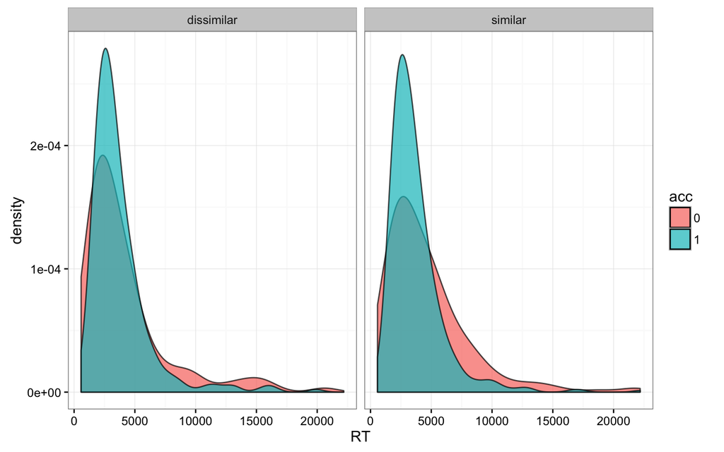

Plot accuracy by similarity.

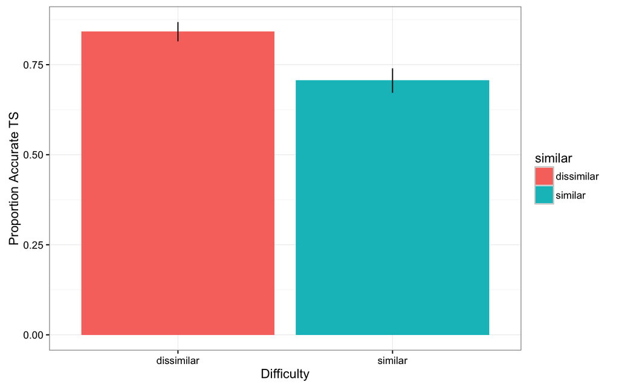

Plot mean RT by accuracy and similarity.

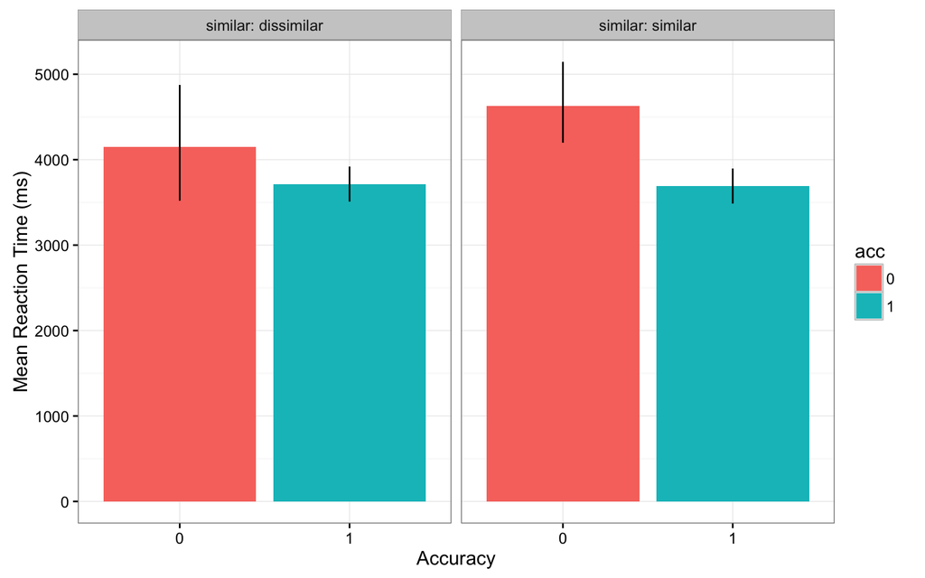

## 5.1 Analyses

Linear mixed-effects models predicting RT based on similarity and accuracy.

```r
#more complex random effects structures fail to converge.
#expect random effects slopes to vary more for ID than target- effects of similarity and accuracy should vary more by participant than target.

glm_RT_full <- lmer(RT ~ similar + acc +
                          (similar + acc | ID),
                         data = d_filt_rt_log, REML = FALSE)

glm_RT_interaction <- lmer(RT ~ similar * acc +
                          (similar + acc | ID),
                         data = d_filt_rt_log, REML = FALSE)

glm_RT_sim <- lmer(RT ~ similar +
                          (similar + acc | ID),
                         data = d_filt_rt_log, REML = FALSE)

glm_RT_acc <- lmer(RT ~ acc +
                          (similar + acc | ID),
                         data = d_filt_rt_log, REML = FALSE)

glm_RT_age <- lmer(RT ~ similar + acc + age_months +
                          (similar + acc | ID),
                         data = d_filt_rt_log, REML = FALSE)

glm_RT_age_sim <- lmer(RT ~  acc + similar * age_months +
                          (similar + acc | ID),
                         data = d_filt_rt_log, REML = FALSE)

glm_RT_age_acc <- lmer(RT ~ similar + acc * age_months +
                          (similar + acc | ID),
                         data = d_filt_rt_log, REML = FALSE)
```

Summary of maximal model (without interaction term)

```r
summary(glm_RT_full)
```

```
## Linear mixed model fit by maximum likelihood  ['lmerMod']
## Formula: RT ~ similar + acc + (similar + acc | ID)
##    Data: d_filt_rt_log
##
##      AIC      BIC   logLik deviance df.resid
##   1930.1   1982.4   -955.1   1910.1     1373
##
## Scaled residuals:
##     Min      1Q  Median      3Q     Max
## -3.4053 -0.6207 -0.0996  0.5022  4.1297
##
## Random effects:
##  Groups   Name           Variance Std.Dev. Corr
##  ID       (Intercept)    0.16888  0.4110
##           similarsimilar 0.02208  0.1486   -0.44
##           acc            0.01592  0.1262   -0.70 -0.34
##  Residual                0.20101  0.4483
## Number of obs: 1383, groups:  ID, 73
##
## Fixed effects:
##                Estimate Std. Error t value
## (Intercept)     8.22322    0.05760  142.76
## similarsimilar  0.02604    0.03009    0.87
## acc            -0.17763    0.03483   -5.10
##
## Correlation of Fixed Effects:
##             (Intr) smlrsm
## similarsmlr -0.444
## acc         -0.666  0.041
```

Fixed effects coeffiencients for full model.

|  | Estimate | Std. Error | t value |
| --- | --- | --- | --- |
| (Intercept) | 8.22 | 0.06 | 142.76 |
| similarsimilar | 0.03 | 0.03 | 0.87 |
| acc | -0.18 | 0.03 | -5.10 |

Compare model fits as significance test.

Test for effect of accuracy.

|  | Df | AIC | BIC | logLik | deviance | Chisq | Chi Df | Pr(>Chisq) |
| --- | --- | --- | --- | --- | --- | --- | --- | --- |
| glm_RT_sim | 9 | 1949.758 | 1996.846 | -965.8790 | 1931.758 | NA | NA | NA |
| glm_RT_full | 10 | 1930.118 | 1982.438 | -955.0588 | 1910.118 | 21.64043 | 1 | 3.3e-06 |

Test for effect of similarity.

|  | Df | AIC | BIC | logLik | deviance | Chisq | Chi Df | Pr(>Chisq) |
| --- | --- | --- | --- | --- | --- | --- | --- | --- |
| glm_RT_acc | 9 | 1928.861 | 1975.949 | -955.4306 | 1910.861 | NA | NA | NA |
| glm_RT_full | 10 | 1930.118 | 1982.438 | -955.0588 | 1910.118 | 0.7437776 | 1 | 0.3884535 |

Test for effect of age.

|  | Df | AIC | BIC | logLik | deviance | Chisq | Chi Df | Pr(>Chisq) |
| --- | --- | --- | --- | --- | --- | --- | --- | --- |
| glm_RT_full | 10 | 1930.118 | 1982.438 | -955.0588 | 1910.118 | NA | NA | NA |
| glm_RT_age | 11 | 1924.828 | 1982.380 | -951.4139 | 1902.828 | 7.289653 | 1 | 0.0069353 |

Test for interaction effect of age and acc.

|  | Df | AIC | BIC | logLik | deviance | Chisq | Chi Df | Pr(>Chisq) |
| --- | --- | --- | --- | --- | --- | --- | --- | --- |
| glm_RT_age | 11 | 1924.828 | 1982.380 | -951.4139 | 1902.828 | NA | NA | NA |
| glm_RT_age_acc | 12 | 1926.548 | 1989.332 | -951.2739 | 1902.548 | 0.280032 | 1 | 0.5966802 |

Test for interaction effect of age and sim.

|  | Df | AIC | BIC | logLik | deviance | Chisq | Chi Df | Pr(>Chisq) |
| --- | --- | --- | --- | --- | --- | --- | --- | --- |
| glm_RT_age | 11 | 1924.828 | 1982.380 | -951.4139 | 1902.828 | NA | NA | NA |
| glm_RT_age_sim | 12 | 1926.340 | 1989.124 | -951.1698 | 1902.340 | 0.4883471 | 1 | 0.4846655 |

Test for effect of interaction between accuracy and similarity.

|  | Df | AIC | BIC | logLik | deviance | Chisq | Chi Df | Pr(>Chisq) |
| --- | --- | --- | --- | --- | --- | --- | --- | --- |
| glm_RT_full | 10 | 1930.118 | 1982.438 | -955.0588 | 1910.118 | NA | NA | NA |
| glm_RT_interaction | 11 | 1930.846 | 1988.398 | -954.4228 | 1908.846 | 1.271844 | 1 | 0.2594211 |

Get mean RT by similarity and accuracy.

```r
describeBy(d_filt_rt$RT, d_filt_rt$similar)
```

```
## group: dissimilar
##   vars   n    mean      sd median trimmed    mad min   max range skew
## 1    1 691 3783.56 2732.25   3052 3274.82 1482.6 577 20608 20031 2.83
##   kurtosis     se
## 1    10.24 103.94
## --------------------------------------------------------
## group: similar
##   vars   n    mean      sd median trimmed    mad min   max range skew
## 1    1 692 3963.03 2703.68 3229.5  3502.1 1674.6 718 22183 21465 2.79
##   kurtosis     se
## 1    11.65 102.78
```

```r
describeBy(d_filt_rt$RT, d_filt_rt$acc)
```

```
## group: 0
##   vars   n mean      sd median trimmed     mad min   max range skew
## 1    1 312 4459 3536.01   3308 3817.99 2257.26 698 22075 21377 2.15
##   kurtosis     se
## 1     5.77 200.19
## --------------------------------------------------------
## group: 1
##   vars    n    mean      sd median trimmed    mad min   max range skew
## 1    1 1071 3702.75 2404.54   3105 3296.17 1405.5 577 22183 21606 2.99
##   kurtosis    se
## 1    13.07 73.47
```

```r
#accurate trials
d_filt_rt_t <- filter(d_filt_rt, acc == "1") %>%
  select(ID, trial, RT, similar) %>%
  group_by(ID, similar) %>%
  summarise(RT = mean(RT)) %>%
  spread(similar, RT)

# paired t-test
test_acc <- t.test(d_filt_rt_t$similar, d_filt_rt_t$dissimilar,paired=TRUE)
test_acc
```

```
##
##  Paired t-test
##
## data:  d_filt_rt_t$similar and d_filt_rt_t$dissimilar
## t = -0.86582, df = 72, p-value = 0.3895
## alternative hypothesis: true difference in means is not equal to 0
## 95 percent confidence interval:
##  -433.9976  171.1598
## sample estimates:
## mean of the differences
##               -131.4189
```

```r
#inaccurate trials
d_filt_rt_t <- filter(d_filt_rt, acc == "0") %>%
  select(ID, trial, RT, similar) %>%
  group_by(ID, similar) %>%
  summarise(RT = mean(RT)) %>%
  spread(similar, RT)

# paired t-test
test_inacc <- t.test(d_filt_rt_t$similar, d_filt_rt_t$dissimilar,paired=TRUE)
test_inacc
```

```
##
##  Paired t-test
##
## data:  d_filt_rt_t$similar and d_filt_rt_t$dissimilar
## t = 0.81659, df = 53, p-value = 0.4178
## alternative hypothesis: true difference in means is not equal to 0
## 95 percent confidence interval:
##  -483.3188 1147.1090
## sample estimates:
## mean of the differences
##                331.8951
```

The effect of similarity was not significant among accurate trials, *t* = -0.87, *p* = 0.39, nor was it significant for inaccurate trials, *t* = 0.82, *p* = 0.42.

Do individual differences in RT differential (for similar vs. dissimilar) correlate with accuracy?

```r
d_filt_rt$acc <- as.numeric(as.character(d_filt_rt$acc))

d_filt_rt_id <- d_filt_rt %>%
  group_by(ID) %>%
  mutate(rt_acc = mean(RT[acc == 1])) %>%
  mutate(rt_inacc = mean(RT[acc == 0])) %>%
  mutate(rt_sim = mean(RT[similar == "similar"])) %>%
  mutate(rt_dissim = mean(RT[similar == "dissimilar"])) %>%
  mutate(rt_acc_diff = rt_inacc - rt_acc) %>%
  mutate(rt_sim_diff = rt_sim - rt_dissim) %>%
  mutate(avg_acc = mean(acc))
```

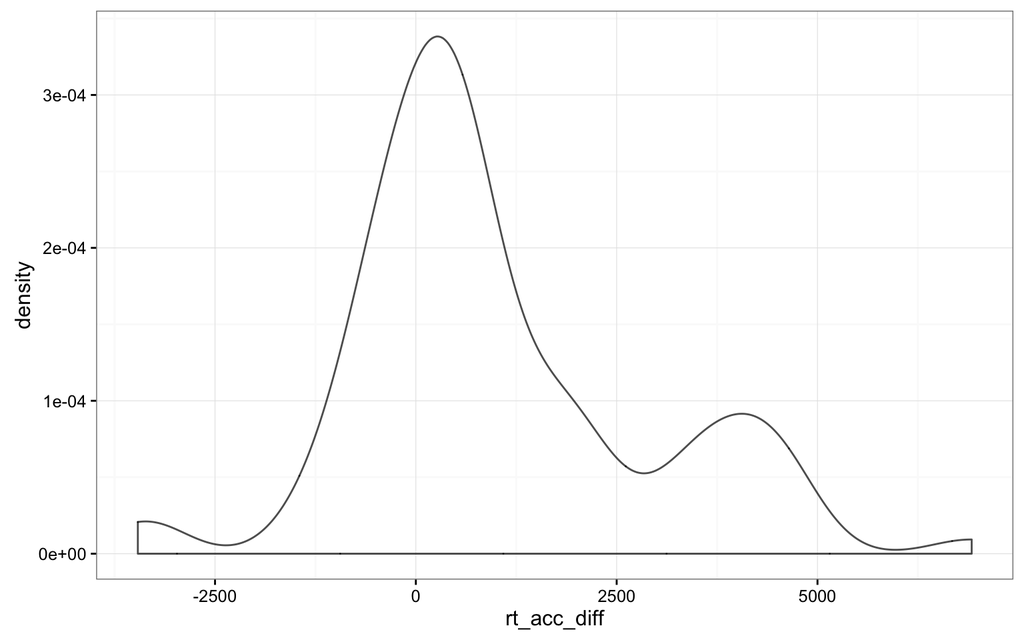

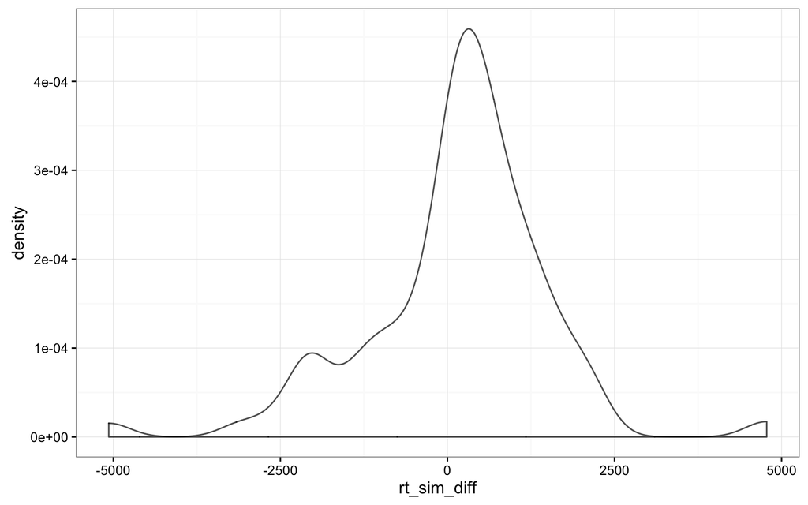

Correlate differentials with accuracy.

```r
d_filt_rt_id <- d_filt_rt_id %>%
  select(ID, rt_acc_diff, rt_sim_diff, avg_acc) %>%
  distinct %>%
  ungroup %>%
  select(-ID)

rcorr(as.matrix(d_filt_rt_id))
```

```
##             rt_acc_diff rt_sim_diff avg_acc
## rt_acc_diff        1.00        0.29   -0.06
## rt_sim_diff        0.29        1.00    0.15
## avg_acc           -0.06        0.15    1.00
##
## n= 73
##
##
## P
##             rt_acc_diff rt_sim_diff avg_acc
## rt_acc_diff             0.0130      0.6169
## rt_sim_diff 0.0130                  0.2059
## avg_acc     0.6169      0.2059
```

```r
corstarsl(d_filt_rt_id)
```

```
##             rt_acc_diff rt_sim_diff
## rt_acc_diff
## rt_sim_diff      0.29*
## avg_acc          -0.06        0.15
```

Individual differences in RT differentials (i.e., RT for similar - similar; RT for inacc - acc) were correlated with each other but not with accuracy. This is expected as accuracy and similarity are correlated.

## 5.2 Summary of Touchscreen Results

Accuracy was higher for dissimilar items.

T-tests showed that the effect of similarity was not significant among accurate trials, *t* = -0.87, *p* = 0.39, nor was it significant for inaccurate trials, *t* = 0.82, *p* = 0.42.

Individual differences in RT differentials (i.e., RT for similar - similar; RT for inacc - acc) were correlated with each other but not with accuracy. This is expected as accuracy and similarity are correlated.